# HR Analysis

# Remove duplicates from train data

```r
train <- distinct(train)
```

```
                   Step 3: Analyse and Visulaize Data
```

```r
summary(train)
```

```
##   employee_id                department          region
##  1      :    1   Sales & Marketing:16840   region_2 :12343
##  10     :    1   Operations       :11348   region_22: 6428
##  100    :    1   Procurement      : 7138   region_7 : 4843
##  1000   :    1   Technology       : 7138   region_15: 2808
##  10000  :    1   Analytics        : 5352   region_13: 2648
##  10001  :    1   Finance          : 2536   region_26: 2260
##  (Other):54802   (Other)          : 4456   (Other)  :23478
##             education        gender               recruitment_channel
##                  : 2409   f     :16312   other              :30446
##  Bachelor's      :36669   gender:    0   recruitment_channel:    0
##  Below Secondary :  805   m     :38496   referred           : 1142
##  education       :    0                  sourcing           :23220
##  Master's & above:14925
##
##
##  no_of_trainings      age                  previous_year_rating
##  1      :44378   30     : 3665                       : 4124
##  2      : 7987   31     : 3534   1                   : 6223
##  3      : 1776   32     : 3534   2                   : 4225
##  4      :  468   29     : 3405   3                   :18618
##  5      :  128   33     : 3210   4                   : 9877
##  6      :   44   28     : 3147   5                   :11741
##  (Other):   27   (Other):34313   previous_year_rating:    0
##  length_of_service       KPIs_met >80%        awards_won?    avg_training_score
##  3      : 7033     0            :35517   0          :53538   50     : 2716
##  4      : 6836     1            :19291   1          : 1270   49     : 2681
##  2      : 6684     KPIs_met >80%:    0   awards_won?:    0   48     : 2437
##  5      : 5832                                               51     : 2347
##  7      : 5551                                               60     : 2155
##  6      : 4734                                               59     : 2064
##  (Other):18138                                               (Other):40408
##       is_promoted
##  0          :50140
##  1          : 4668
##  is_promoted:    0
##
##
##
##
```

# Visualize every variable with target variable

# Education and Promotion

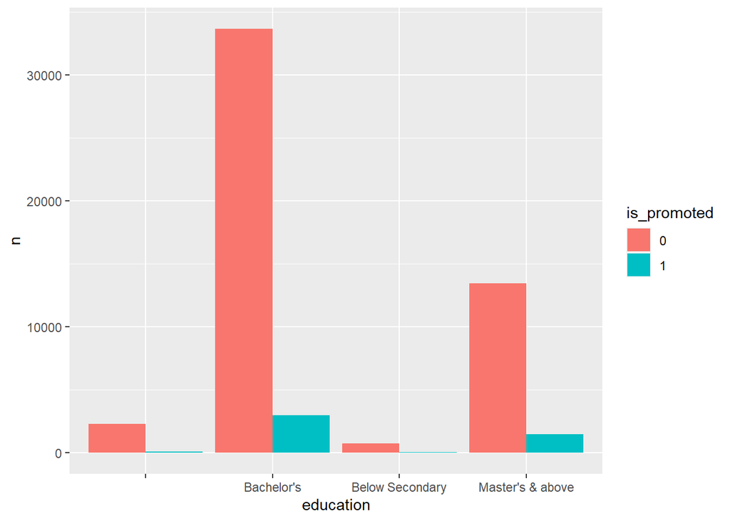

```r
train %>%
    group_by(education, is_promoted) %>%
    summarise(n=n()) %>%
    ggplot(aes(x=education, y=n, fill=is_promoted)) + geom_bar(stat='identity', position='dodge')
```

- In terms of education, promotion is focused on Bachelor’s and above degree owners.

# department and promotion

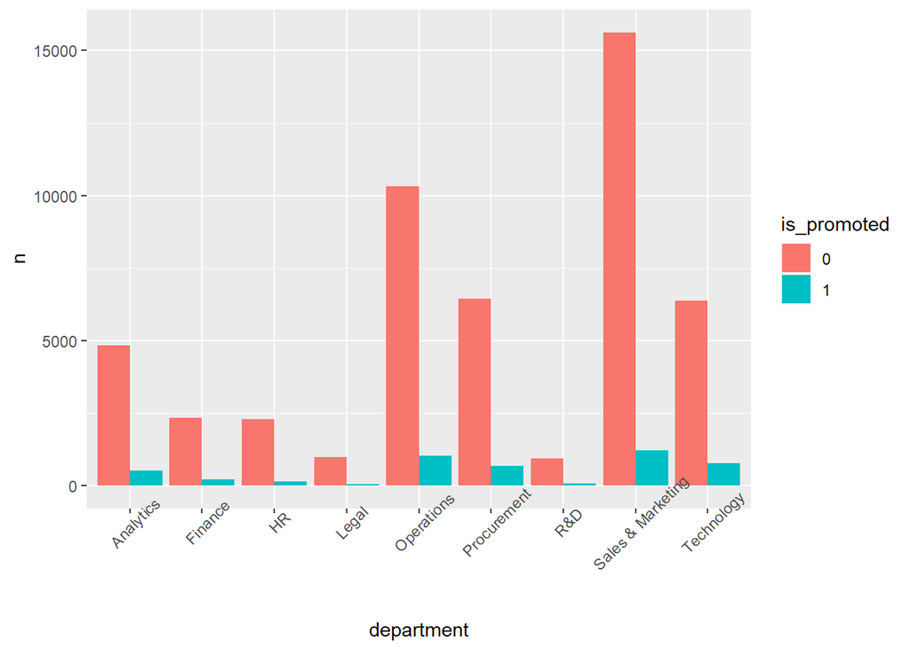

```r
train %>%
    group_by(department, is_promoted) %>%
    summarise(n=n()) %>%
    ggplot(aes(x=department, y=n, group=is_promoted, fill=is_promoted)) + geom_bar(stat='identity', position='dodge') + theme(axis.text.x= element_text(angle=45))
```

# Gender and promotion

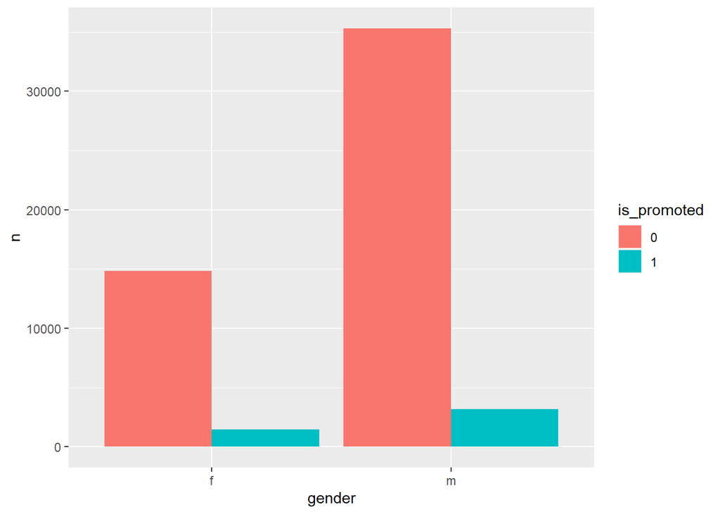

```r
train %>%
    group_by(gender, is_promoted) %>%
    summarise(n=n()) %>%
    ggplot(aes(x=gender, y=n, fill=is_promoted)) + geom_bar(stat='identity', position='dodge')
```

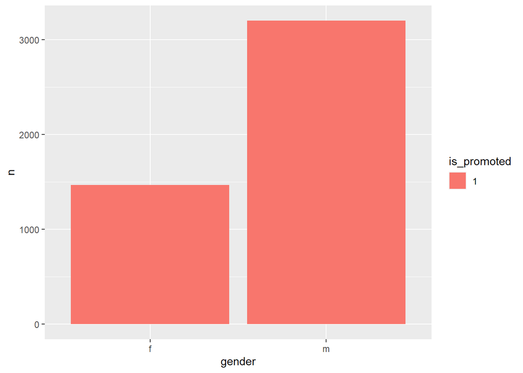

```r
train %>%
    group_by(gender, is_promoted) %>%
    summarise(n=n()) %>%
    filter(is_promoted==1) %>%
    ggplot(aes(x=gender, y=n, fill=is_promoted)) + geom_bar(stat='identity', position='dodge')
```

- The ratio of gender among employees is nearly identical to the ratio of gender among promotions.

# recruitment_channel and promotion

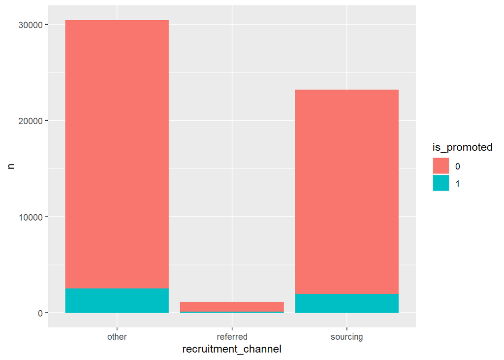

```r
train %>%
    group_by(recruitment_channel, is_promoted) %>%
    summarise(n=n()) %>%
    ggplot(aes(x=recruitment_channel, y=n, fill=is_promoted)) + geom_bar(stat='identity')
```

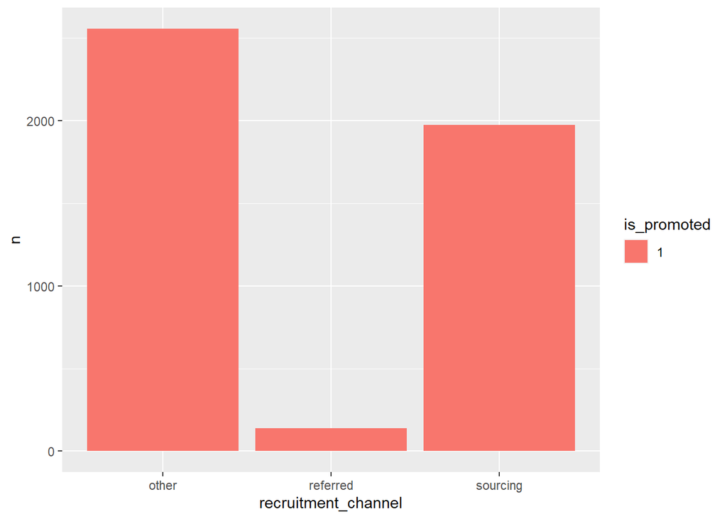

```r
train %>%
    group_by(recruitment_channel, is_promoted) %>%
    summarise(n=n()) %>%
    filter(is_promoted==1) %>%
    ggplot(aes(x=recruitment_channel, y=n, fill=is_promoted)) + geom_bar(stat='identity')
```

- Recruitment channel is not decisive factor to be promoted.

# no_of_trainings and promotion

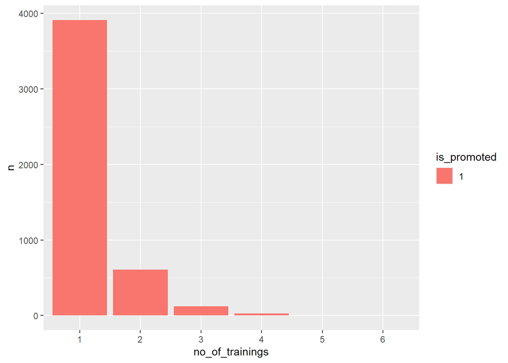

```r
train %>%
    group_by(no_of_trainings, is_promoted) %>%
    summarise(n=n()) %>%
    filter(is_promoted==1) %>%
    ggplot(aes(x=no_of_trainings, y=n, fill=is_promoted)) + geom_bar(stat='identity',position='dodge')
```

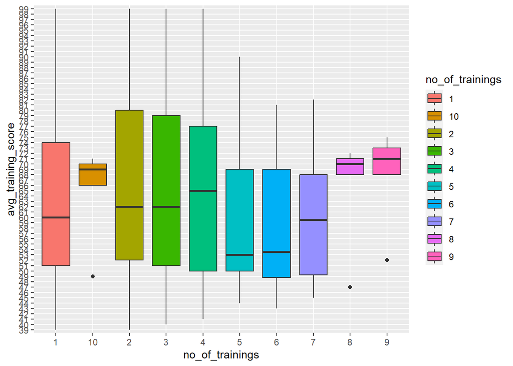

```r
# no_of_trainings and avg_training_score
train %>%
    summarise(no_of_trainings=no_of_trainings, avg_training_score=avg_training_score) %>%
    ggplot(aes(x=no_of_trainings, y=avg_training_score, group=no_of_trainings, fill=no_of_trainings)) + geom_boxplot()
```

# Age and promotion

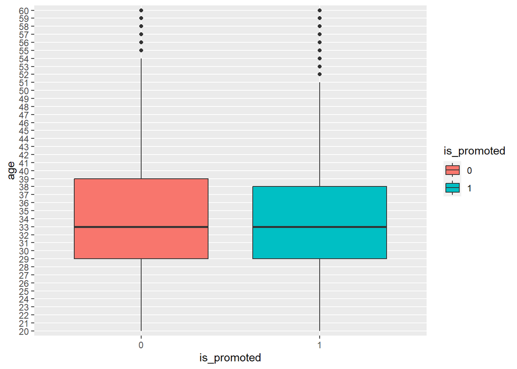

```r
train %>%
    group_by(is_promoted) %>%
    summarise(age=age, n=n()) %>%
    arrange(age) %>%
    ggplot(aes(x=is_promoted, y=age, group=is_promoted, fill=is_promoted)) + geom_boxplot()
```

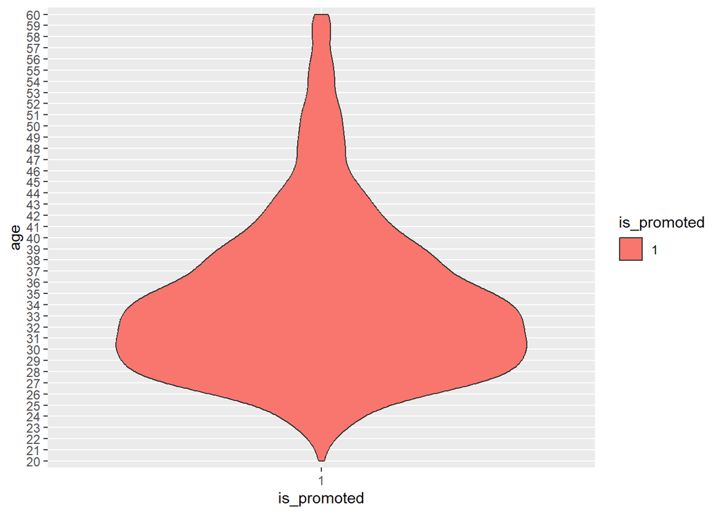

```r
train %>%
    group_by(is_promoted) %>%
    summarise(age=age, n=n()) %>%
    arrange(age) %>%
    filter(is_promoted==1) %>%
    ggplot(aes(x=is_promoted, y=age, group=is_promoted, fill=is_promoted)) + geom_violin()
```

- Promotion is focused on early 30s, and the chance is drastically decreased for over mid 40 years employees.

# previous year rating and promotion

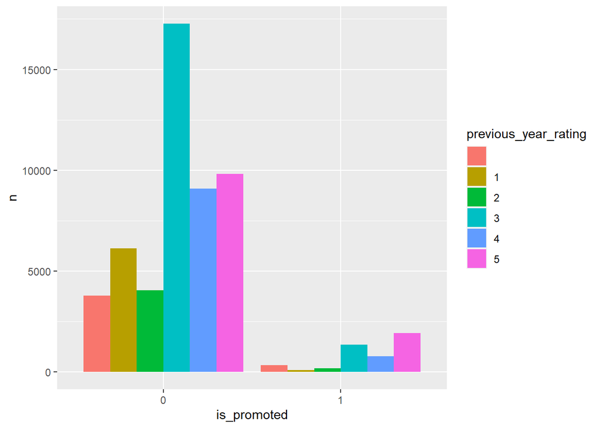

```r
train %>%
    group_by(previous_year_rating, is_promoted) %>%
    summarise(n=n()) %>%
    ggplot(aes(x=is_promoted, y=n, group=previous_year_rating, fill=previous_year_rating)) + geom_bar(stat='identity', position='dodge')
```

- Employees who got rated 1, 2 are merely promoted, but, in terms of ratio, employees who got rated 5 show highest promotion rate.

# Length of service and promotion

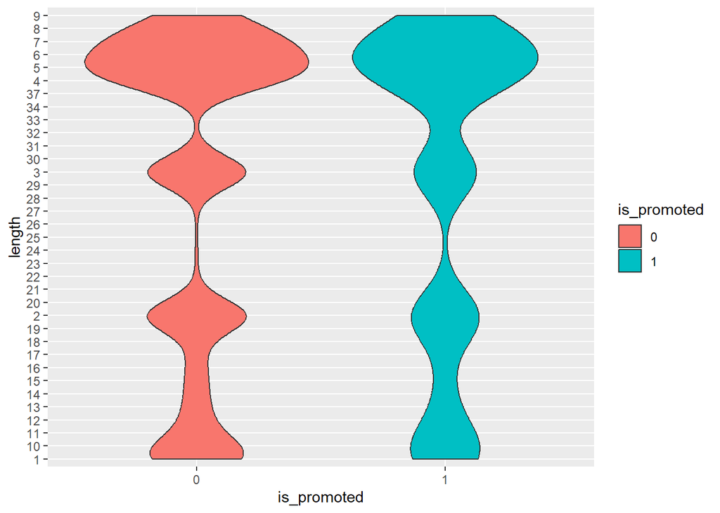

```r
train %>%
    group_by(is_promoted) %>%
    summarise(length=length_of_service) %>%
    #filter(is_promoted==1) %>%
    ggplot(aes(x=is_promoted, y=length, group=is_promoted, fill=is_promoted)) + geom_violin()
```

- Most promotion is focused on employees under 10 year length of services.